# Travel Package Purchase

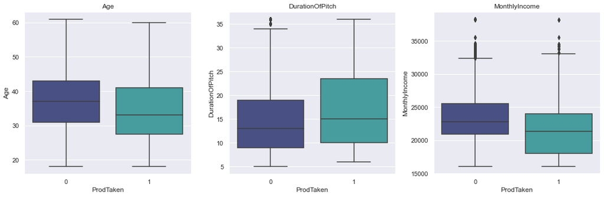

```python
cols = ['Age','DurationOfPitch', 'MonthlyIncome']
show_boxplots(cols, 'ProdTaken')
```

- On average those who have taken the product are younger.
- The duration of pitch from the rep is longer on average amongst customers who have taken the product.
- Monthly income is lower amongst those customer who have taken the product.

| ProdTaken TypeofContact | 0 | 1 | All | % - 0 | % - 1 |
| --- | --- | --- | --- | --- | --- |
| Company Invited | 932 | 273 | 1205 | 77.34 | 22.66 |
| All | 3325 | 795 | 4120 | 80.70 | 19.30 |
| Self Enquiry | 2393 | 522 | 2915 | 82.09 | 17.91 |

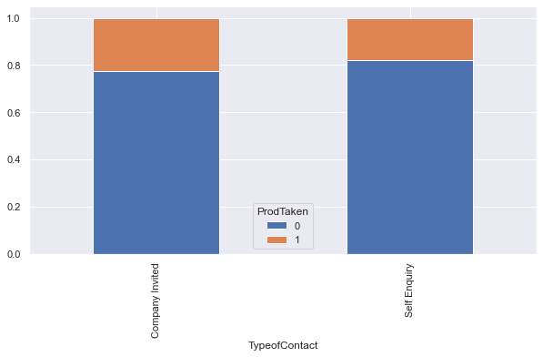

```python
stacked_plot(df.TypeofContact, df.ProdTaken)
```

- Percentage is similar amongst different types of contracts.

| ProdTaken CityTier | 0 | 1 | All | % - 0 | % - 1 |
| --- | --- | --- | --- | --- | --- |
| 2 | 119 | 43 | 162 | 73.46 | 26.54 |
| 3 | 976 | 311 | 1287 | 75.84 | 24.16 |
| All | 3325 | 795 | 4120 | 80.70 | 19.30 |
| 1 | 2230 | 441 | 2671 | 83.49 | 16.51 |

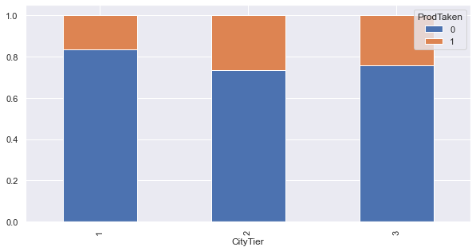

```python
stacked_plot(df.CityTier, df.ProdTaken)
```

- City tier two has a greater percentage of those customers that have taken the product.
- City tier three has the second highest percentage of those customers who have taken the product.

| ProdTaken DurationOfPitch | 0 | 1 | All | % - 0 | % - 1 |
| --- | --- | --- | --- | --- | --- |
| 31.0 | 50 | 31 | 81 | 61.73 | 38.27 |
| 19.0 | 33 | 19 | 52 | 63.46 | 36.54 |
| 30.0 | 58 | 28 | 86 | 67.44 | 32.56 |
| 28.0 | 38 | 17 | 55 | 69.09 | 30.91 |
| 29.0 | 43 | 19 | 62 | 69.35 | 30.65 |
| 18.0 | 49 | 19 | 68 | 72.06 | 27.94 |
| 23.0 | 56 | 20 | 76 | 73.68 | 26.32 |
| 20.0 | 41 | 14 | 55 | 74.55 | 25.45 |
| 24.0 | 50 | 16 | 66 | 75.76 | 24.24 |
| 36.0 | 32 | 10 | 42 | 76.19 | 23.81 |
| 22.0 | 58 | 18 | 76 | 76.32 | 23.68 |
| 21.0 | 51 | 15 | 66 | 77.27 | 22.73 |
| 33.0 | 38 | 11 | 49 | 77.55 | 22.45 |
| 25.0 | 52 | 14 | 66 | 78.79 | 21.21 |
| 32.0 | 56 | 15 | 71 | 78.87 | 21.13 |
| 16.0 | 195 | 51 | 246 | 79.27 | 20.73 |
| 27.0 | 54 | 14 | 68 | 79.41 | 20.59 |
| 10.0 | 166 | 40 | 206 | 80.58 | 19.42 |
| 11.0 | 142 | 34 | 176 | 80.68 | 19.32 |
| All | 3325 | 795 | 4120 | 80.70 | 19.30 |
| 12.0 | 145 | 33 | 178 | 81.46 | 18.54 |
| 15.0 | 203 | 44 | 247 | 82.19 | 17.81 |
| 8.0 | 238 | 48 | 286 | 83.22 | 16.78 |
| 26.0 | 56 | 11 | 67 | 83.58 | 16.42 |
| 14.0 | 186 | 36 | 222 | 83.78 | 16.22 |
| 9.0 | 345 | 65 | 410 | 84.15 | 15.85 |
| 13.0 | 174 | 32 | 206 | 84.47 | 15.53 |
| 17.0 | 131 | 24 | 155 | 84.52 | 15.48 |
| 7.0 | 263 | 47 | 310 | 84.84 | 15.16 |
| 34.0 | 40 | 7 | 47 | 85.11 | 14.89 |
| 6.0 | 232 | 37 | 269 | 86.25 | 13.75 |
| 35.0 | 45 | 6 | 51 | 88.24 | 11.76 |
| 5.0 | 5 | 0 | 5 | 100.00 | 0.00 |

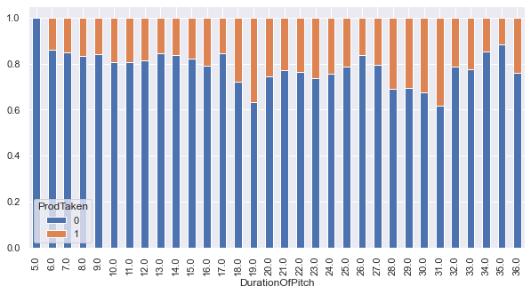

```python
stacked_plot(df.DurationOfPitch, df.ProdTaken)
```

- Duration of pitch versus those who have taken the product is looks to be greatest between the range of 19 to 31.

| ProdTaken Occupation | 0 | 1 | All | % - 0 | % - 1 |
| --- | --- | --- | --- | --- | --- |
| Free Lancer | 0 | 2 | 2 | 0.00 | 100.00 |
| Large Business | 268 | 109 | 377 | 71.09 | 28.91 |
| All | 3325 | 795 | 4120 | 80.70 | 19.30 |
| Small Business | 1421 | 325 | 1746 | 81.39 | 18.61 |
| Salaried | 1636 | 359 | 1995 | 82.01 | 17.99 |

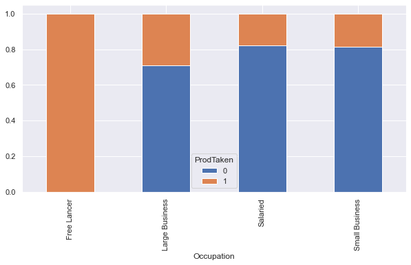

```python
stacked_plot(df.Occupation, df.ProdTaken)
```

- All free lancers have taken the product but that there is a small percentage of free lancers in the dataset.
- Large business holds the greatest percentage of those customers that have taken the product.

| ProdTaken Gender | 0 | 1 | All | % - 0 | % - 1 |
| --- | --- | --- | --- | --- | --- |
| Male | 1962 | 496 | 2458 | 79.82 | 20.18 |
| All | 3325 | 795 | 4120 | 80.70 | 19.30 |
| Female | 1363 | 299 | 1662 | 82.01 | 17.99 |

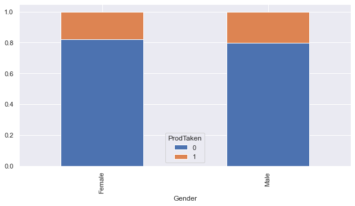

```python
stacked_plot(df.Gender, df.ProdTaken)
```

- The distribution is similar amongst genders.

| ProdTaken NumberOfPersonVisiting | 0 | 1 | All | % - 0 | % - 1 |
| --- | --- | --- | --- | --- | --- |
| 2 | 872 | 215 | 1087 | 80.22 | 19.78 |
| 4 | 749 | 180 | 929 | 80.62 | 19.38 |
| 3 | 1673 | 400 | 2073 | 80.70 | 19.30 |
| All | 3325 | 795 | 4120 | 80.70 | 19.30 |
| 1 | 28 | 0 | 28 | 100.00 | 0.00 |
| 5 | 3 | 0 | 3 | 100.00 | 0.00 |

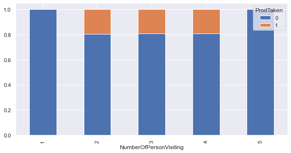

```python
stacked_plot(df.NumberOfPersonVisiting, df.ProdTaken)
```

- The greatest percentage of those customers who have taken the product is greatest between the ranges of 2 to 4 people visiting.

| ProdTaken NumberOfFollowups | 0 | 1 | All | % - 0 | % - 1 |
| --- | --- | --- | --- | --- | --- |
| 6.0 | 75 | 49 | 124 | 60.48 | 39.52 |
| 5.0 | 514 | 171 | 685 | 75.04 | 24.96 |
| All | 3325 | 795 | 4120 | 80.70 | 19.30 |
| 4.0 | 1465 | 342 | 1807 | 81.07 | 18.93 |
| 3.0 | 961 | 193 | 1154 | 83.28 | 16.72 |
| 1.0 | 125 | 19 | 144 | 86.81 | 13.19 |
| 2.0 | 185 | 21 | 206 | 89.81 | 10.19 |

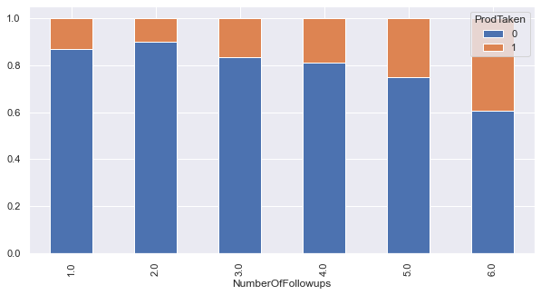

```python
stacked_plot(df.NumberOfFollowups, df.ProdTaken)
```

- Greatest percentage of customers who have taken the product is greatest with 6 followups.
- The seconds highest percentage is 5 followups. Four followups is in third place.

| ProdTaken ProductPitched | 0 | 1 | All | % - 0 | % - 1 |
| --- | --- | --- | --- | --- | --- |
| Basic | 1128 | 483 | 1611 | 70.02 | 29.98 |
| All | 3325 | 795 | 4120 | 80.70 | 19.30 |
| Standard | 618 | 119 | 737 | 83.85 | 16.15 |
| Deluxe | 1253 | 165 | 1418 | 88.36 | 11.64 |
| King | 95 | 9 | 104 | 91.35 | 8.65 |
| Super Deluxe | 231 | 19 | 250 | 92.40 | 7.60 |

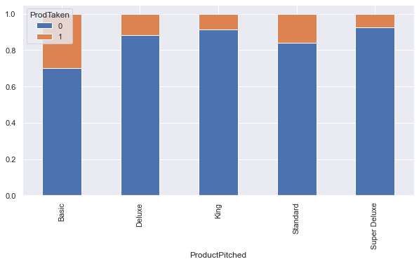

```python
stacked_plot(df.ProductPitched, df.ProdTaken)
```

- Basic holds the greatest percentage amongst those customers who have taken the product.
- Standard hold the second highest percentage amongst those customers who have taken the product.

| ProdTaken PreferredPropertyStar | 0 | 1 | All | % - 0 | % - 1 |
| --- | --- | --- | --- | --- | --- |
| 5.0 | 584 | 216 | 800 | 73.00 | 27.00 |
| 4.0 | 625 | 159 | 784 | 79.72 | 20.28 |
| All | 3325 | 795 | 4120 | 80.70 | 19.30 |
| 3.0 | 2116 | 420 | 2536 | 83.44 | 16.56 |

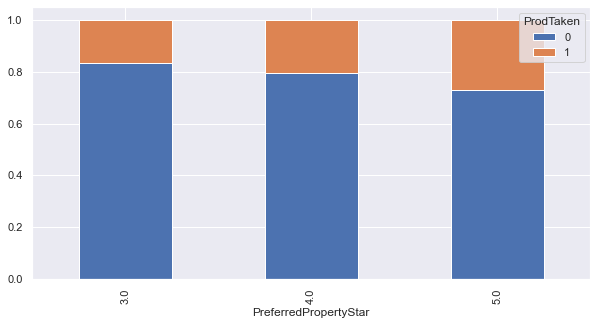

```python
stacked_plot(df.PreferredPropertyStar, df.ProdTaken)
```

- Five property stars holds the highest percentage of those customers who have taken the product.

| ProdTaken MaritalStatus | 0 | 1 | All | % - 0 | % - 1 |
| --- | --- | --- | --- | --- | --- |
| Unmarried | 1619 | 512 | 2131 | 75.97 | 24.03 |
| All | 3325 | 795 | 4120 | 80.70 | 19.30 |
| Married | 1706 | 283 | 1989 | 85.77 | 14.23 |

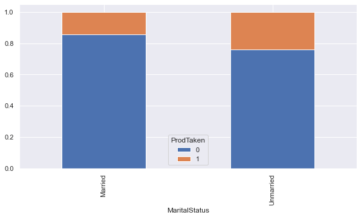

```python
stacked_plot(df.MaritalStatus, df.ProdTaken)
```

- Unmarried customers hold the greatest percentage of those who have taken the product.

| ProdTaken NumberOfTrips | 0 | 1 | All | % - 0 | % - 1 |
| --- | --- | --- | --- | --- | --- |
| 7.0 | 137 | 56 | 193 | 70.98 | 29.02 |
| 8.0 | 74 | 29 | 103 | 71.84 | 28.16 |
| 2.0 | 992 | 274 | 1266 | 78.36 | 21.64 |
| 3.0 | 800 | 193 | 993 | 80.56 | 19.44 |
| All | 3325 | 795 | 4120 | 80.70 | 19.30 |
| 6.0 | 231 | 52 | 283 | 81.63 | 18.37 |
| 1.0 | 384 | 83 | 467 | 82.23 | 17.77 |
| 5.0 | 339 | 56 | 395 | 85.82 | 14.18 |
| 4.0 | 368 | 52 | 420 | 87.62 | 12.38 |

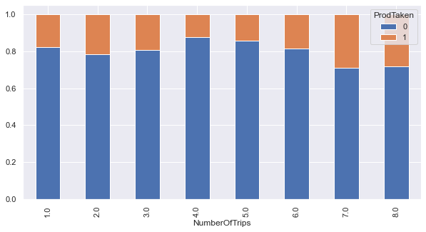

```python
stacked_plot(df.NumberOfTrips, df.ProdTaken)
```

- Seven trips is holds the greatest percentage of the product taken.

| ProdTaken Passport | 0 | 1 | All | % - 0 | % - 1 |
| --- | --- | --- | --- | --- | --- |
| 1 | 779 | 435 | 1214 | 64.17 | 35.83 |
| All | 3325 | 795 | 4120 | 80.70 | 19.30 |
| 0 | 2546 | 360 | 2906 | 87.61 | 12.39 |

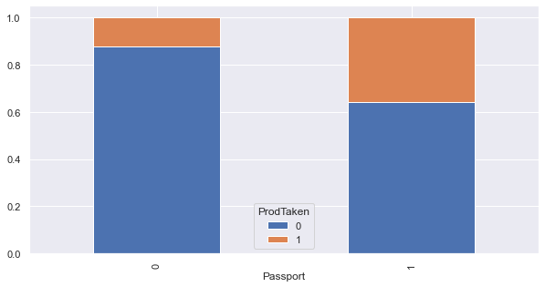

```python
stacked_plot(df.Passport, df.ProdTaken)
```

- Those customers with a passport hold the greatest percentage of products taken.

| ProdTaken PitchSatisfactionScore | 0 | 1 | All | % - 0 | % - 1 |
| --- | --- | --- | --- | --- | --- |
| 5 | 621 | 175 | 796 | 78.02 | 21.98 |
| 3 | 983 | 274 | 1257 | 78.20 | 21.80 |
| All | 3325 | 795 | 4120 | 80.70 | 19.30 |
| 4 | 623 | 142 | 765 | 81.44 | 18.56 |
| 2 | 419 | 78 | 497 | 84.31 | 15.69 |
| 1 | 679 | 126 | 805 | 84.35 | 15.65 |

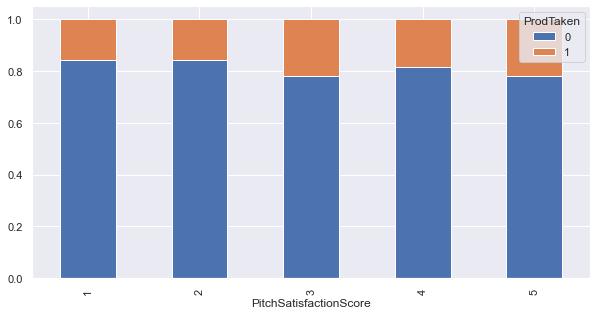

```python
stacked_plot(df.PitchSatisfactionScore, df.ProdTaken)
```

| ProdTaken OwnCar | 0 | 1 | All | % - 0 | % - 1 |
| --- | --- | --- | --- | --- | --- |
| 0 | 1283 | 316 | 1599 | 80.24 | 19.76 |
| All | 3325 | 795 | 4120 | 80.70 | 19.30 |
| 1 | 2042 | 479 | 2521 | 81.00 | 19.00 |

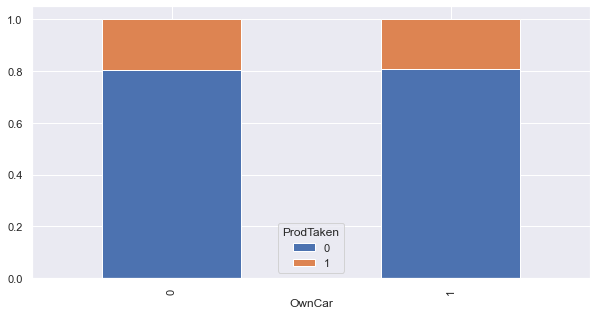

```python
stacked_plot(df.OwnCar, df.ProdTaken)
```

- The distribution of products taken amongst those customers who own cars is similar.

| ProdTaken NumberOfChildrenVisiting | 0 | 1 | All | % - 0 | % - 1 |
| --- | --- | --- | --- | --- | --- |
| 3.0 | 234 | 59 | 293 | 79.86 | 20.14 |
| 2.0 | 953 | 231 | 1184 | 80.49 | 19.51 |
| All | 3325 | 795 | 4120 | 80.70 | 19.30 |
| 1.0 | 1451 | 345 | 1796 | 80.79 | 19.21 |
| 0.0 | 687 | 160 | 847 | 81.11 | 18.89 |

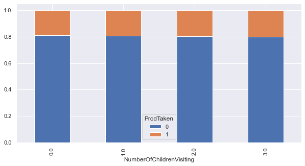

```python
stacked_plot(df.NumberOfChildrenVisiting, df.ProdTaken)
```

- Distribution is similar amongst the number of children visiting.

| ProdTaken Designation | 0 | 1 | All | % - 0 | % - 1 |
| --- | --- | --- | --- | --- | --- |
| Executive | 1128 | 483 | 1611 | 70.02 | 29.98 |
| All | 3325 | 795 | 4120 | 80.70 | 19.30 |
| Senior Manager | 618 | 119 | 737 | 83.85 | 16.15 |
| Manager | 1253 | 165 | 1418 | 88.36 | 11.64 |
| VP | 95 | 9 | 104 | 91.35 | 8.65 |
| AVP | 231 | 19 | 250 | 92.40 | 7.60 |

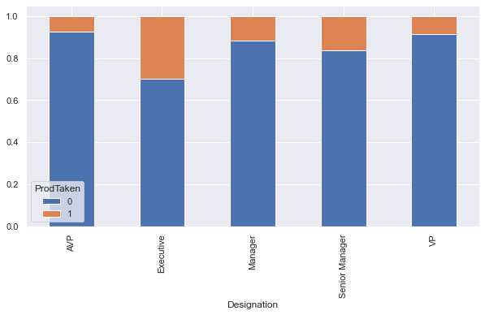

```python
stacked_plot(df.Designation, df.ProdTaken)
```

- Executive holds the greatest designation amongst customers who took the product.
- Senior Manager hold the seconds highest designation amongst customers who have taken the product.

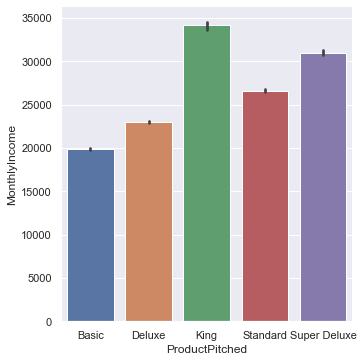

```python
sns.catplot(x="ProductPitched",y="MonthlyIncome", data=df, kind="bar");
```

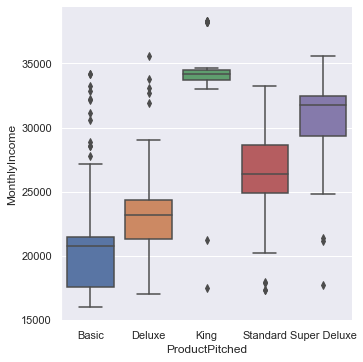

```python
sns.catplot(x="ProductPitched",y="MonthlyIncome", data=df, kind="box");
```

- Products pitched to customers based on monthly income show the king package to be pitched to those customers with higher monthly incomes.
- Salepeople pitch the basic package to those customers with lower monthly incomes.
- The basic package has more outliers in it's distribution.

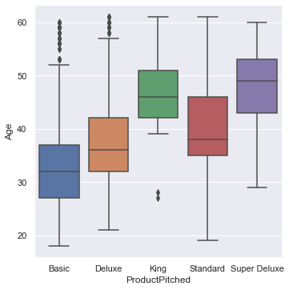

```python
sns.catplot(x="ProductPitched",y="Age", data=df, kind="box");
```

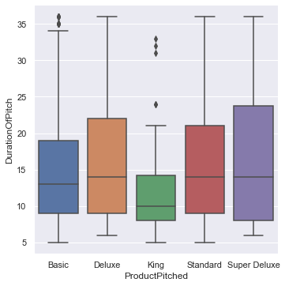

```python
sns.catplot(x="ProductPitched",y="DurationOfPitch", data=df, kind="box");
```

## Data Preprocessing

top

```python
cols = df.select_dtypes(include='category').columns
dummies = pd.get_dummies(df, columns=cols, drop_first=True)
dummies.head()
```

|  | ProdTaken | Age | CityTier | DurationOfPitch | NumberOfPersonVisiting | NumberOfFollowups | PreferredPropertyStar | NumberOfTrips | Passport | PitchSatisfactionScore | ... | Gender_Male | ProductPitched_Deluxe | ProductPitched_King | ProductPitched_Standard | ProductPitched_Super Deluxe | MaritalStatus_Unmarried | Designation_Executive | Designation_Manager | Designation_Senior Manager | Designation_VP |
| --- | --- | --- | --- | --- | --- | --- | --- | --- | --- | --- | --- | --- | --- | --- | --- | --- | --- | --- | --- | --- | --- |
| 0 | 1 | 41.0 | 3 | 6.0 | 3 | 3.0 | 3.0 | 1.0 | 1 | 2 | ... | 0 | 1 | 0 | 0 | 0 | 1 | 0 | 1 | 0 | 0 |
| 1 | 0 | 49.0 | 1 | 14.0 | 3 | 4.0 | 4.0 | 2.0 | 0 | 3 | ... | 1 | 1 | 0 | 0 | 0 | 1 | 0 | 1 | 0 | 0 |
| 2 | 1 | 37.0 | 1 | 8.0 | 3 | 4.0 | 3.0 | 7.0 | 1 | 3 | ... | 1 | 0 | 0 | 0 | 0 | 1 | 1 | 0 | 0 | 0 |
| 3 | 0 | 33.0 | 1 | 9.0 | 2 | 3.0 | 3.0 | 2.0 | 1 | 5 | ... | 0 | 0 | 0 | 0 | 0 | 1 | 1 | 0 | 0 | 0 |
| 5 | 0 | 32.0 | 1 | 8.0 | 3 | 3.0 | 3.0 | 1.0 | 0 | 5 | ... | 1 | 0 | 0 | 0 | 0 | 1 | 1 | 0 | 0 | 0 |

5 rows × 27 columns

## Splitting Dataset

top

```python
X = dummies.drop('ProdTaken', axis=1)
X.head()
```

|  | Age | CityTier | DurationOfPitch | NumberOfPersonVisiting | NumberOfFollowups | PreferredPropertyStar | NumberOfTrips | Passport | PitchSatisfactionScore | OwnCar | ... | Gender_Male | ProductPitched_Deluxe | ProductPitched_King | ProductPitched_Standard | ProductPitched_Super Deluxe | MaritalStatus_Unmarried | Designation_Executive | Designation_Manager | Designation_Senior Manager | Designation_VP |
| --- | --- | --- | --- | --- | --- | --- | --- | --- | --- | --- | --- | --- | --- | --- | --- | --- | --- | --- | --- | --- | --- |
| 0 | 41.0 | 3 | 6.0 | 3 | 3.0 | 3.0 | 1.0 | 1 | 2 | 1 | ... | 0 | 1 | 0 | 0 | 0 | 1 | 0 | 1 | 0 | 0 |
| 1 | 49.0 | 1 | 14.0 | 3 | 4.0 | 4.0 | 2.0 | 0 | 3 | 1 | ... | 1 | 1 | 0 | 0 | 0 | 1 | 0 | 1 | 0 | 0 |
| 2 | 37.0 | 1 | 8.0 | 3 | 4.0 | 3.0 | 7.0 | 1 | 3 | 0 | ... | 1 | 0 | 0 | 0 | 0 | 1 | 1 | 0 | 0 | 0 |
| 3 | 33.0 | 1 | 9.0 | 2 | 3.0 | 3.0 | 2.0 | 1 | 5 | 1 | ... | 0 | 0 | 0 | 0 | 0 | 1 | 1 | 0 | 0 | 0 |
| 5 | 32.0 | 1 | 8.0 | 3 | 3.0 | 3.0 | 1.0 | 0 | 5 | 1 | ... | 1 | 0 | 0 | 0 | 0 | 1 | 1 | 0 | 0 | 0 |

5 rows × 26 columns

```python
y = dummies.pop('ProdTaken')
y.head()
```

```
0    1
1    0
2    1
3    0
5    0
Name: ProdTaken, dtype: int64
```

```python
X_train, X_test, y_train, y_test = train_test_split(X, y, test_size=0.3, random_state=1, stratify=y)
print(X_train.shape, X_test.shape)
```

```
(2884, 26) (1236, 26)
```

```python
y.value_counts(normalize=True)
```

```
0    0.807039
1    0.192961
Name: ProdTaken, dtype: float64
```

## Model Building

top

### Model evaluation criterion

#### Model can make wrong predictions as:

- Predicting a customer will purchase the package when in fact the customer won't purchase the wellness package.
- Predicting the customer will not purchase the package when in fact the customer will purchase the package.

#### Which case is more important?

1. If the model predicts a customer will not purchase the package, but the customer in fact will purchase the package.
2. If the model predicts a customer will purchase a package but doesn't actually purchase the package then this is loss of resources used.

#### Which metric to optimize?

- We would want F1-Score to be maximized, the greater the F1-Score higher the chances of predicting both the classes correctly.

**Let's define function to provide metric scores on train and test set and a function to show confusion matrix so that we do not have use the same code repetitively while evaluating models.**

```python
##  Function to calculate different metric scores of the model - Accuracy, Recall and Precision
def get_metrics_score(model, flag=True):
    '''
    model : classifier to predict values of X
    flag: Flag to print metric score dataframe. (default=True)
    '''
    # defining an empty list to store train and test results
    scores = []
    pred_train = model.predict(X_train)
    pred_test = model.predict(X_test)
    train_acc = model.score(X_train,y_train)
    test_acc = model.score(X_test,y_test)
    train_recall = metrics.recall_score(y_train,pred_train)
    test_recall = metrics.recall_score(y_test,pred_test)
    train_precision = metrics.precision_score(y_train,pred_train)
    test_precision = metrics.precision_score(y_test,pred_test)
    train_f1 = f1_score(y_train,pred_train)
    test_f1 = f1_score(y_test,pred_test)
    scores.extend(
        (
            train_acc, test_acc,
            train_recall, test_recall,
            train_precision, test_precision,
            train_f1, test_f1
        )
    )

    # If the flag is set to True then only the following print statements will be dispayed. The default value is set to True.
    if flag == True:
        metric_names = [
            'Train Accuracy', 'Test Accuracy', 'Train Recall', 'Test Recall',
            'Train Precision', 'Test Precision', 'Train F1-Score', 'Test F1-Score'
        ]
        cols = ['Metric', 'Score']
        records = [(name, score) for name, score in zip(metric_names, scores)]
        display(pd.DataFrame.from_records(records, columns=cols, index='Metric').T)

    return scores # returning the list with train and test scores
```

```python
## Function to create confusion matrix
def make_confusion_matrix(model,  y_actual, labels=[1, 0], xtest=X_test):
    """
    model : classifier to predict values of X
    y_actual : ground truth
    """
    y_predict = model.predict(xtest)
    cm = metrics.confusion_matrix(y_actual, y_predict, labels=[0, 1])
    df_cm = pd.DataFrame(cm, index=["Yes", "No"], columns=["Yes", "No"])

    group_counts = [f"{value:0.0f}" for value in cm.flatten()]
    group_percentages = [f"{value:.2%}" for value in cm.flatten()/np.sum(cm)]

    labels = [f"{gc}\n{gp}" for gc, gp in zip(group_counts, group_percentages)]
    labels = np.asarray(labels).reshape(2,2)

    plt.figure(figsize = (10, 7))
    sns.heatmap(df_cm, annot=labels, fmt='')
    plt.ylabel("Actual", fontsize=14)
    plt.xlabel("Predicted", fontsize=14);
```

## Decision Tree Classifier

top

| Metric | Train Accuracy | Test Accuracy | Train Recall | Test Recall | Train Precision | Test Precision | Train F1-Score | Test F1-Score |
| --- | --- | --- | --- | --- | --- | --- | --- | --- |
| Score | 1.0 | 0.892395 | 1.0 | 0.719665 | 1.0 | 0.722689 | 1.0 | 0.721174 |

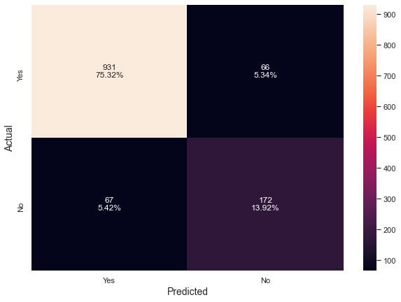

```python
#Fitting the model
d_tree = DecisionTreeClassifier(random_state=1)
d_tree.fit(X_train,y_train)

#Calculating different metrics
get_metrics_score(d_tree)

#Creating confusion matrix
make_confusion_matrix(d_tree,y_test)
```

### Hyperparameter tuning

```python
# Choose the type of classifier
dtree_estimator = DecisionTreeClassifier(class_weight={0: 0.80, 1: 0.20}, random_state=1)

# Grid of pararmeters to choose from
parameters = {
    'max_depth': np.arange(2, 30),
    'min_samples_leaf': [1, 2, 5, 7, 10],
    'max_leaf_nodes': [2, 3, 5, 10, 15],
    'min_impurity_decrease': [0.0001, 0.001, 0.01, 0.1]
}

# Type of scoring used to compare parameter combinations
scorer = metrics.make_scorer(metrics.f1_score)

# Run the grid search
grid_obj = GridSearchCV(dtree_estimator, parameters, scoring=scorer, n_jobs=-1)
grid_obj = grid_obj.fit(X_train, y_train)

# Set the clf to the best combinations of parameters
dtree_estimator = grid_obj.best_estimator_

# Fit the best algorithm to the data.
dtree_estimator.fit(X_train, y_train)
```

```
DecisionTreeClassifier(class_weight={0: 0.8, 1: 0.2}, max_depth=7,
                       max_leaf_nodes=15, min_impurity_decrease=0.0001,
                       random_state=1)
```

| Metric | Train Accuracy | Test Accuracy | Train Recall | Test Recall | Train Precision | Test Precision | Train F1-Score | Test F1-Score |
| --- | --- | --- | --- | --- | --- | --- | --- | --- |
| Score | 0.84466 | 0.830906 | 0.196043 | 0.146444 | 0.990909 | 0.875 | 0.327327 | 0.250896 |

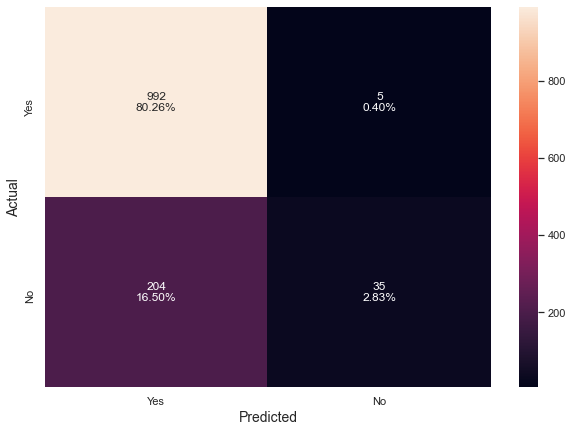

```python
get_metrics_score(dtree_estimator)
make_confusion_matrix(dtree_estimator, y_test)
```

## Random Forest Classifier

top

| Metric | Train Accuracy | Test Accuracy | Train Recall | Test Recall | Train Precision | Test Precision | Train F1-Score | Test F1-Score |
| --- | --- | --- | --- | --- | --- | --- | --- | --- |
| Score | 1.0 | 0.908576 | 1.0 | 0.556485 | 1.0 | 0.95 | 1.0 | 0.701847 |

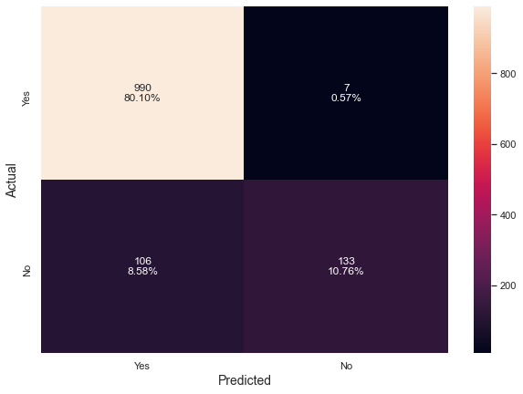

```python
#Fitting the model
rf_estimator = RandomForestClassifier(random_state=1)
rf_estimator.fit(X_train,y_train)

#Calculating different metrics
get_metrics_score(rf_estimator)

#Creating confusion matrix
make_confusion_matrix(rf_estimator,y_test)
```

### Hyperparamter tuning

```python
# Choose the type of classifier.
rf_tuned = RandomForestClassifier(class_weight={0: 0.80, 1: 0.20},
                                  random_state=1,
                                  oob_score=True,
                                  bootstrap=True)

parameters = {
    'max_depth': np.arange(5, 30, 5),
    'max_features': ['sqrt','log2', None],
    'min_samples_leaf': np.arange(1, 15, 5),
    'min_samples_split': np.arange(2, 20, 5),
    'n_estimators': np.arange(10, 110, 10)
}


# Type of scoring used to compare parameter combinations
scorer = metrics.make_scorer(metrics.f1_score)

# Run the grid search
grid_obj = GridSearchCV(rf_tuned, parameters, scoring=scorer, cv=5, n_jobs=-1)
grid_obj = grid_obj.fit(X_train, y_train)

# Set the clf to the best combination of parameters
rf_tuned = grid_obj.best_estimator_

# Fit the best algorithm to the data.
rf_tuned.fit(X_train, y_train)
```

```
RandomForestClassifier(class_weight={0: 0.8, 1: 0.2}, max_depth=25,
                       max_features=None, n_estimators=50, oob_score=True,
                       random_state=1)
```

| Metric | Train Accuracy | Test Accuracy | Train Recall | Test Recall | Train Precision | Test Precision | Train F1-Score | Test F1-Score |
| --- | --- | --- | --- | --- | --- | --- | --- | --- |
| Score | 1.0 | 0.917476 | 1.0 | 0.656904 | 1.0 | 0.887006 | 1.0 | 0.754808 |

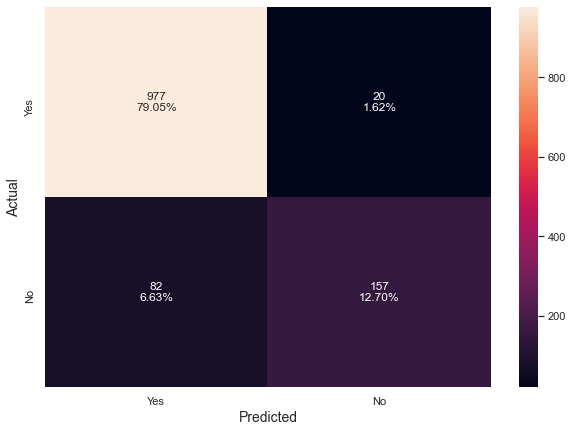

```python
#Calculating different metrics
get_metrics_score(rf_tuned)

#Creating confusion matrix
make_confusion_matrix(rf_tuned, y_test)
```

## Bagging Classifier

top

| Metric | Train Accuracy | Test Accuracy | Train Recall | Test Recall | Train Precision | Test Precision | Train F1-Score | Test F1-Score |
| --- | --- | --- | --- | --- | --- | --- | --- | --- |
| Score | 0.995839 | 0.907767 | 0.978417 | 0.598326 | 1.0 | 0.888199 | 0.989091 | 0.715 |

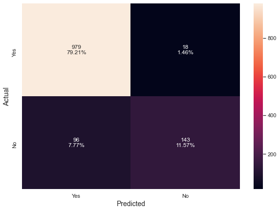

```python
#Fitting the model
bagging_classifier = BaggingClassifier(random_state=1)
bagging_classifier.fit(X_train,y_train)

#Calculating different metrics
get_metrics_score(bagging_classifier)

#Creating confusion matrix
make_confusion_matrix(bagging_classifier,y_test)
```

### Hyperparameter tuning

```python
# Choose the type of classifier.
bagging_estimator_tuned = BaggingClassifier(random_state=1)

# Grid of parameters to choose from
parameters = {
    'max_samples': [0.7, 0.8, 0.9, 1],
    'max_features': [0.7, 0.8, 0.9, 1],
    'n_estimators' : [10, 20, 30, 40, 50],
}

# Type of scoring used to compare parameter combinations
scorer = metrics.make_scorer(metrics.f1_score)

# Run the grid search
grid_obj = GridSearchCV(bagging_estimator_tuned, parameters, scoring=scorer, cv=5, n_jobs=-1)
grid_obj = grid_obj.fit(X_train, y_train)

# Set the clf to the best combination of parameters
bagging_estimator_tuned = grid_obj.best_estimator_

# Fit the best algorithm to the data.
bagging_estimator_tuned.fit(X_train, y_train)
```

```
BaggingClassifier(max_features=0.9, max_samples=0.9, n_estimators=40,
                  random_state=1)
```

| Metric | Train Accuracy | Test Accuracy | Train Recall | Test Recall | Train Precision | Test Precision | Train F1-Score | Test F1-Score |
| --- | --- | --- | --- | --- | --- | --- | --- | --- |
| Score | 0.999307 | 0.911812 | 0.996403 | 0.577406 | 1.0 | 0.945205 | 0.998198 | 0.716883 |

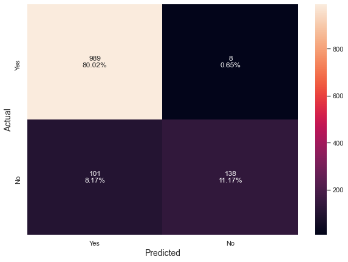

```python
#Calculating different metrics
get_metrics_score(bagging_estimator_tuned)

#Creating confusion matrix
make_confusion_matrix(bagging_estimator_tuned,y_test)
```

## AdaBoost Classifier

top

| Metric | Train Accuracy | Test Accuracy | Train Recall | Test Recall | Train Precision | Test Precision | Train F1-Score | Test F1-Score |
| --- | --- | --- | --- | --- | --- | --- | --- | --- |
| Score | 0.847434 | 0.839806 | 0.348921 | 0.32636 | 0.713235 | 0.678261 | 0.468599 | 0.440678 |

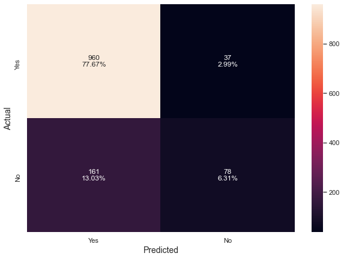

```python
abc = AdaBoostClassifier(random_state=1)
abc.fit(X_train, y_train)
get_metrics_score(abc)
make_confusion_matrix(abc, y_test)
```

### Hyperparameter Tuning

```python
# Choose the type of classifier.
abc_tuned = AdaBoostClassifier(random_state=1)

# Grid of parameters to choose from
parameters = {
    #Let's try different max_depth for base_estimator
    "base_estimator":[
        DecisionTreeClassifier(max_depth=1),DecisionTreeClassifier(max_depth=2),
        DecisionTreeClassifier(max_depth=3), DecisionTreeClassifier(max_depth=4),
        DecisionTreeClassifier(max_depth=5),DecisionTreeClassifier(max_depth=6),
        DecisionTreeClassifier(max_depth=7), DecisionTreeClassifier(max_depth=8)
    ],
    "n_estimators": np.arange(10, 110, 10),
    "learning_rate":np.arange(0.1, 2, 0.1)
}

# Type of scoring used to compare parameter  combinations
scorer = metrics.make_scorer(metrics.f1_score)

# Run the grid search
grid_obj = GridSearchCV(abc_tuned, parameters, scoring=scorer, cv=5, n_jobs=-1)
grid_obj = grid_obj.fit(X_train, y_train)

# Set the clf to the best combination of parameters
abc_tuned = grid_obj.best_estimator_

# Fit the best algorithm to the data.
abc_tuned.fit(X_train, y_train)
```

```
AdaBoostClassifier(base_estimator=DecisionTreeClassifier(max_depth=7),
                   learning_rate=0.2, n_estimators=90, random_state=1)
```

| Metric | Train Accuracy | Test Accuracy | Train Recall | Test Recall | Train Precision | Test Precision | Train F1-Score | Test F1-Score |
| --- | --- | --- | --- | --- | --- | --- | --- | --- |
| Score | 1.0 | 0.91343 | 1.0 | 0.598326 | 1.0 | 0.928571 | 1.0 | 0.727735 |

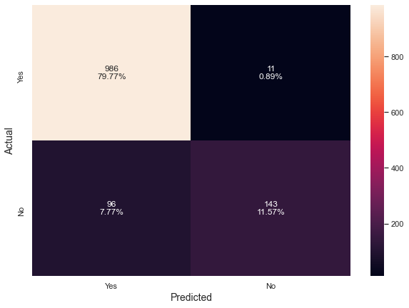

```python
#Calculating different metrics
get_metrics_score(abc_tuned)

#Creating confusion matrix
make_confusion_matrix(abc_tuned,y_test)
```

## Gradient Boosting Classifier

top

| Metric | Train Accuracy | Test Accuracy | Train Recall | Test Recall | Train Precision | Test Precision | Train F1-Score | Test F1-Score |
| --- | --- | --- | --- | --- | --- | --- | --- | --- |
| Score | 0.893551 | 0.869741 | 0.494604 | 0.430962 | 0.913621 | 0.804688 | 0.641774 | 0.561308 |

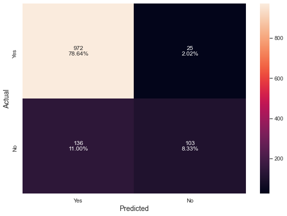

```python
#Fitting the model
gb_classifier = GradientBoostingClassifier(random_state=1)
gb_classifier.fit(X_train,y_train)

#Calculating different metrics
get_metrics_score(gb_classifier)

#Creating confusion matrix
make_confusion_matrix(gb_classifier,y_test)
```

### Hyperparameter Tuning

```python
# Choose the type of classifier.
gbc_tuned = GradientBoostingClassifier(init=AdaBoostClassifier(random_state=1), random_state=1)

# Grid of parameters to choose from
parameters = {
    "n_estimators": np.arange(100, 300, 50),
    "subsample":[0.5, 0.6, 0.7, 0.8, 0.9, 1],
    "max_features":[0.7, 0.8, 0.9, 1]
}

# Type of scoring used to compare parameter combinations
scorer = metrics.make_scorer(metrics.f1_score)

# Run the grid search
grid_obj = GridSearchCV(gbc_tuned, parameters, scoring=scorer, cv=5, n_jobs=-1)
grid_obj = grid_obj.fit(X_train, y_train)

# Set the clf to the best combination of parameters
gbc_tuned = grid_obj.best_estimator_

# Fit the best algorithm to the data.
gbc_tuned.fit(X_train, y_train)
```

```
GradientBoostingClassifier(init=AdaBoostClassifier(random_state=1),
                           max_features=0.9, n_estimators=250, random_state=1,
                           subsample=0.8)
```

| Metric | Train Accuracy | Test Accuracy | Train Recall | Test Recall | Train Precision | Test Precision | Train F1-Score | Test F1-Score |
| --- | --- | --- | --- | --- | --- | --- | --- | --- |
| Score | 0.929265 | 0.893204 | 0.663669 | 0.539749 | 0.955959 | 0.854305 | 0.783439 | 0.661538 |

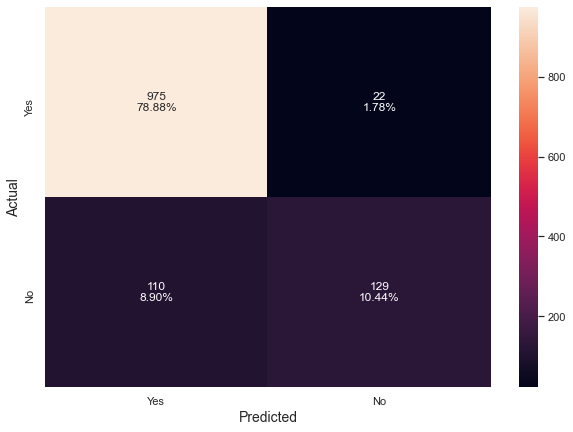

```python
#Calculating different metrics
get_metrics_score(gbc_tuned)

#Creating confusion matrix
make_confusion_matrix(gbc_tuned, y_test)
```

## XGBoost Classifier

top

| Metric | Train Accuracy | Test Accuracy | Train Recall | Test Recall | Train Precision | Test Precision | Train F1-Score | Test F1-Score |
| --- | --- | --- | --- | --- | --- | --- | --- | --- |
| Score | 1.0 | 0.915049 | 1.0 | 0.656904 | 1.0 | 0.872222 | 1.0 | 0.749403 |

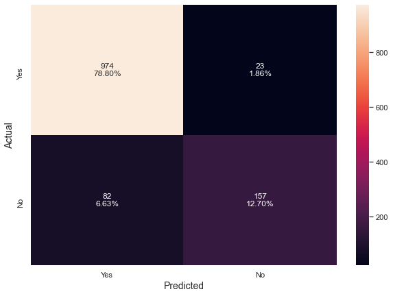

```python
#Fitting the model
xgb_classifier = XGBClassifier(random_state=1, eval_metric='logloss')
xgb_classifier.fit(X_train,y_train)

#Calculating different metrics
get_metrics_score(xgb_classifier)

#Creating confusion matrix
make_confusion_matrix(xgb_classifier, y_test)
```

```python
# Choose the type of classifier.
xgb_tuned = XGBClassifier(random_state=1, eval_metric='logloss')

# Grid of parameters to choose from
parameters = {
    "n_estimators": np.arange(25, 100, 25),
    "scale_pos_weight": [2, 5, 7, 9],
    "subsample": [0.7, 0.9, 1],
    "learning_rate": [0.05, 0.1, 0.2, 0.4, 0.8, 1],
    "colsample_bytree": [0.7, 0.8, 0.9, 1],
    "colsample_bylevel": [0.5, 0.6, 0.7, 0.8, 0.9, 1]
}

# Type of scoring used to compare parameter combinations
scorer = metrics.make_scorer(metrics.f1_score)

# Run the grid search
grid_obj = GridSearchCV(xgb_tuned, parameters, scoring=scorer, cv=5, n_jobs=-1)
grid_obj = grid_obj.fit(X_train, y_train)

# Set the clf to the best combination of parameters
xgb_tuned = grid_obj.best_estimator_

# Fit the best algorithm to the data.
xgb_tuned.fit(X_train, y_train)
```

```
XGBClassifier(base_score=0.5, booster='gbtree', colsample_bylevel=0.8,
              colsample_bynode=1, colsample_bytree=0.7, eval_metric='logloss',
              gamma=0, gpu_id=-1, importance_type='gain',
              interaction_constraints='', learning_rate=0.4, max_delta_step=0,
              max_depth=6, min_child_weight=1, missing=nan,
              monotone_constraints='()', n_estimators=75, n_jobs=12,
              num_parallel_tree=1, random_state=1, reg_alpha=0, reg_lambda=1,
              scale_pos_weight=9, subsample=1, tree_method='exact',
              validate_parameters=1, verbosity=None)
```

| Metric | Train Accuracy | Test Accuracy | Train Recall | Test Recall | Train Precision | Test Precision | Train F1-Score | Test F1-Score |
| --- | --- | --- | --- | --- | --- | --- | --- | --- |
| Score | 0.999653 | 0.915049 | 1.0 | 0.790795 | 0.998205 | 0.77459 | 0.999102 | 0.782609 |

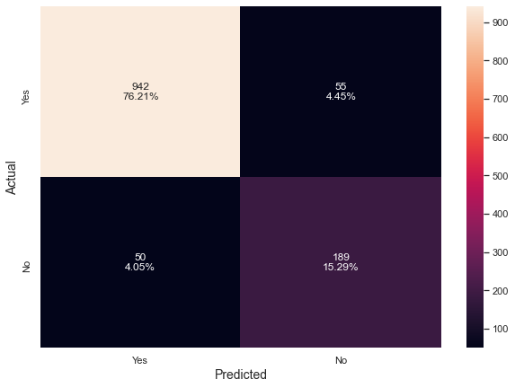

```python
#Calculating different metrics
get_metrics_score(xgb_tuned)

#Creating confusion matrix
make_confusion_matrix(xgb_tuned, y_test)
```

## Stacking Model

top

```python
estimators = [
    ('Bagging Classifier', bagging_estimator_tuned),
    ('Random Forest', rf_tuned),
    ('Gradient Boosting', gbc_tuned),
    ('Decision Tree', dtree_estimator),
    ('AdaBoost Classifier', abc_tuned)
]
final_estimator = xgb_tuned
stacking_classifier= StackingClassifier(estimators=estimators, final_estimator=final_estimator)
stacking_classifier.fit(X_train, y_train)
```

```
StackingClassifier(estimators=[('Bagging Classifier',
                                BaggingClassifier(max_features=0.9,
                                                  max_samples=0.9,
                                                  n_estimators=40,
                                                  random_state=1)),
                               ('Random Forest',
                                RandomForestClassifier(class_weight={0: 0.8,
                                                                     1: 0.2},
                                                       max_depth=25,
                                                       max_features=None,
                                                       n_estimators=50,
                                                       oob_score=True,
                                                       random_state=1)),
                               ('Gradient Boosting',
                                GradientBoostingClassifier(init=AdaBoostClassifie...
                                                 eval_metric='logloss', gamma=0,
                                                 gpu_id=-1,
                                                 importance_type='gain',
                                                 interaction_constraints='',
                                                 learning_rate=0.4,
                                                 max_delta_step=0, max_depth=6,
                                                 min_child_weight=1,
                                                 missing=nan,
                                                 monotone_constraints='()',
                                                 n_estimators=75, n_jobs=12,
                                                 num_parallel_tree=1,
                                                 random_state=1, reg_alpha=0,
                                                 reg_lambda=1,
                                                 scale_pos_weight=9,
                                                 subsample=1,
                                                 tree_method='exact',
                                                 validate_parameters=1,
                                                 verbosity=None))
```

| Metric | Train Accuracy | Test Accuracy | Train Recall | Test Recall | Train Precision | Test Precision | Train F1-Score | Test F1-Score |
| --- | --- | --- | --- | --- | --- | --- | --- | --- |
| Score | 0.998613 | 0.916667 | 1.0 | 0.807531 | 0.992857 | 0.772 | 0.996416 | 0.789366 |

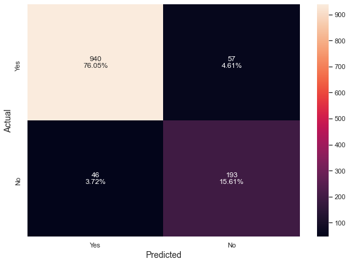

```python
#Calculating different metrics
get_metrics_score(stacking_classifier)

#Creating confusion matrix
make_confusion_matrix(stacking_classifier, y_test)
```

## Comparing Models

top

```python
# defining list of models
models = [
    d_tree, dtree_estimator,
    rf_estimator, rf_tuned,
    bagging_classifier, bagging_estimator_tuned,
    abc, abc_tuned,
    gb_classifier, gbc_tuned,
    xgb_classifier, xgb_tuned,
    stacking_classifier
]

model_names = [
    'Decision Tree', 'Tuned Decision Tree',
    'Random Forest', 'Tuned Random Forest',
    'Bagging Classifier',
    'Bagging Classifier Tuned',
    'AdaBoost Classifier', 'Tuned AdaBoost Classifier',
    'Gradient Boosting Classifier','Tuned Gradient Boosting Classifier',
    'XGBoost Classifier', 'Tuned XGBoost Classifier',
    'Stacking Classifier'
]

results = []
for model, name in zip(models, model_names):
    (acc_train, acc_test,
     recall_train, recall_test,
     precision_train, precision_test,
     f1_train, f1_test) = get_metrics_score(model, False)

    results.append((name, acc_train, acc_test, recall_train, recall_test,
                    precision_train, precision_test, f1_train, f1_test))
```

```python
cols = [
    'Model', 'Train Acc', 'Test Accuracy', 'Train Recall',
    'Test Recall', 'Train Precision', 'Test Precision',
    'Train F1-Score', 'Test F1-Score'
]

comparison_frame = pd.DataFrame.from_records(results, columns=cols, index='Model')

# Sorting models in decreasing order of test f1-score
comparison_frame.sort_values(by='Test F1-Score', ascending=False)
```

| Model | Train Acc | Test Accuracy | Train Recall | Test Recall | Train Precision | Test Precision | Train F1-Score | Test F1-Score |
| --- | --- | --- | --- | --- | --- | --- | --- | --- |
| Stacking Classifier | 0.998613 | 0.916667 | 1.000000 | 0.807531 | 0.992857 | 0.772000 | 0.996416 | 0.789366 |
| Tuned XGBoost Classifier | 0.999653 | 0.915049 | 1.000000 | 0.790795 | 0.998205 | 0.774590 | 0.999102 | 0.782609 |
| Tuned Random Forest | 1.000000 | 0.917476 | 1.000000 | 0.656904 | 1.000000 | 0.887006 | 1.000000 | 0.754808 |
| XGBoost Classifier | 1.000000 | 0.915049 | 1.000000 | 0.656904 | 1.000000 | 0.872222 | 1.000000 | 0.749403 |
| Tuned AdaBoost Classifier | 1.000000 | 0.913430 | 1.000000 | 0.598326 | 1.000000 | 0.928571 | 1.000000 | 0.727735 |
| Decision Tree | 1.000000 | 0.892395 | 1.000000 | 0.719665 | 1.000000 | 0.722689 | 1.000000 | 0.721174 |
| Bagging Classifier Tuned | 0.999307 | 0.911812 | 0.996403 | 0.577406 | 1.000000 | 0.945205 | 0.998198 | 0.716883 |
| Bagging Classifier | 0.995839 | 0.907767 | 0.978417 | 0.598326 | 1.000000 | 0.888199 | 0.989091 | 0.715000 |
| Random Forest | 1.000000 | 0.908576 | 1.000000 | 0.556485 | 1.000000 | 0.950000 | 1.000000 | 0.701847 |
| Tuned Gradient Boosting Classifier | 0.929265 | 0.893204 | 0.663669 | 0.539749 | 0.955959 | 0.854305 | 0.783439 | 0.661538 |
| Gradient Boosting Classifier | 0.893551 | 0.869741 | 0.494604 | 0.430962 | 0.913621 | 0.804688 | 0.641774 | 0.561308 |
| AdaBoost Classifier | 0.847434 | 0.839806 | 0.348921 | 0.326360 | 0.713235 | 0.678261 | 0.468599 | 0.440678 |
| Tuned Decision Tree | 0.844660 | 0.830906 | 0.196043 | 0.146444 | 0.990909 | 0.875000 | 0.327327 | 0.250896 |

top